# Assignment 3

Casey Hon

2022-04-06

```r
suppressWarnings({
  if (! requireNamespace("BiocManager", quietly = TRUE)) {
    install.packages("BiocManager")
  }
  if (! requireNamespace("Biobase", quietly = TRUE)) {
    BiocManager::install("Biobase")
  }
  if (! requireNamespace("fgsea", quietly = TRUE)) {
    BiocManager::install("fgsea")
  }
  if (! requireNamespace("RCurl", quietly = TRUE)) {
    BiocManager::install("RCurl")
  }
  if (! requireNamespace("ggrepel", quietly = TRUE)) {
    BiocManager::install("ggrepel")
  }
  if (! requireNamespace("knitr", quietly = TRUE)) {
    BiocManager::install("knitr")
  }
  if (! requireNamespace("GSA", quietly = TRUE)) {
    BiocManager::install("GSA")
  }
})
```

## Introduction

In Assignment #1, I analyzed RNA-seq data from the study *Alveolar macrophages from persons living with HIV show impaired epigenetic response to Mycobacterium tuberculosis* (Correa-Macedo et al., 2021). Individuals with HIV are at higher risk to have tuberculosis (TB), and this is often due to infection with *Mycobacterium tuberculosis* (*M. tuberculosis*) that rapidly progresses to disease (Correa-Macedo et al., 2021). Alveolar macrophages (AMs) are the first cells in the immune system that interact with *M. tuberculosis*, however their interaction with HIV and antiretroviral therapy (ART) is still unknown (Correa-Macedo et al., 2021). Thus, this study aimed to investigate the transcriptomic and epigenetic response of AMs to *M. tuberculosis* and how HIV and ART play a part in these mechanisms.

AMs were obtained from 16 control subjects who were HIV-free (HC), 20 persons living with HIV receiving ART (PLWH), and 14 subjects who received ART as preexposure prophylaxis (PrEP) to prevent HIV infection. Each sample was challenged with *M. tuberculosis* in vitro.

Some basic statistics:

GEO ID: GSE165708

The original dataset had over 60,000 genes. After using edgeR filtering protocols, 13,780 genes were left. 8 genes were duplicates so those were removed. The data was then normalized using the Trimed Mean of M-values (TMM) method. After normalizing, a Multi-Dimensional Scaling (MDS) plot was used to visualize clustering, but no clear clustering by sample group was seen. There is a pattern that the Healthy Control (HC) group (in pink) tends to be on the left side, the Persons living with HIV (PLWH) group (in green) tending to be more on the right, and the pre-exposure prophylaxis (PrEP) group (in blue) towards the bottom middle. However, compared to other clearly-clustered examples, this is definitely a very obscure distinction between sample groups. I also tried plotting by the other conditions, by patient or by challenged status, but the clustering was even more obscure.

In Assignment #2, I used the normalized expression data and ranked genes according to differential expression, performed thresholded over-representation analysis (ORA), and highlighted dominant themes in the top set of genes. I found that genes are generally more downregulated/have weaker transcriptional response in both the PLWH and PrEP groups, while being more upregulated in the healthy controls. The HC group visually looked more upregulated than the other groups. Through ORA, the top terms were related to cytokine response or Y-linked inheritance, which is expected as we are looking at HIV data that is a sex-related disease and involves infection.

Now that we have the set of genes ranked according to differential expression, this notebook aims to: - conduct non-thresholded gene set enrichment analysis; - visualize the GSEA results in Cytoscape; - visualize a specific pathway/theme of interest.

## Non-thresholded gene set enrichment analysis

```r
library(fgsea)
library(RCurl)

# code from Enrichment Map Protocol (Isserlin 2020)
gmt_url = "http://download.baderlab.org/EM_Genesets/March_01_2021/Human/symbol/"
filenames = getURL(gmt_url)
tc = textConnection(filenames)
contents = readLines(tc)
close(tc)
rx = gregexpr("(?<=<a href=\")(.*.GOBP_AllPathways_no_GO_iea.*.)(.gmt)(?=\">)",
              contents,
              perl = TRUE)
gmt_file = unlist(regmatches(contents, rx))
dest_gmt_file <- paste0("./", gmt_file)
download.file(paste(gmt_url, gmt_file, sep = ""), destfile = dest_gmt_file)

# ran GSEA on local
# run_gsea <- TRUE
# java_version = "11"
# gsea_jar <- "./GSEA_4.2.3/gsea-cli.sh"
# working_dir <- "./Casey_Hon/A3_files"
# rnk_file <- "ranked_genes.rnk"
# analysis_name <- "A3_HIV_Analysis"
#
# if(run_gsea && java_version == "11"){
#   command <- paste("", gsea_jar,  "GSEAPreRanked -gmx", dest_gmt_file, "-rnk",
#                    file.path(working_dir,rnk_file),
#                    "-collapse false -nperm 1000 -scoring_scheme weighted -rpt_label ",
#                    analysis_name,
#                    "  -plot_top_x 20 -rnd_seed 12345  -set_max 200 -set_min 15 -zip_report false -out",
#                    working_dir, " > gsea_output.txt",
#                    sep=" ")
#   system(command)
# } else if (run_gsea) {
#     command <- paste("java  -Xmx1G -cp", gsea_jar,  "xtools.gsea.GseaPreranked -gmx",
#                      dest_gmt_file, "-rnk" ,file.path(working_dir,rnk_file),
#                      "-collapse false -nperm 1000 -permute gene_set -scoring_scheme weighted -rpt_label ",
#                      analysis_name,
#                      "  -num 100 -plot_top_x 20 -rnd_seed 12345  -set_max 200 -set_min 15 -zip_report false -out" ,
#                      working_dir, "-gui false > gsea_output.txt",
#                      sep=" ")
#   system(command)
# }
```

**1. What method did you use? What genesets did you use? Make sure to specify versions and cite your methods.** I used Gene Set Enrichment Analysis through the GSEA Java software (Mootha et al., 2003; Subramananian et al., 2005). I used the Human genesets from the Bader Lab’s March 2021 collection as found here: http://download.baderlab.org/EM_Genesets/March_01_2021/Human/ (Merico et al., 2010).

**2. Summarize your enrichment results.** The positively ranked genes were the upregulated genes while the negative ones were the downregulated genes. Thus, I looked at the resulting gsea report for positive and negative to view the enrichment results.

```r
library(readr)
library(knitr)

# working_dir <- "~/Casey_Hon/A3_files/"

gsea_file <- list.files(path = getwd(), pattern = "\\.GseaPreranked")
pos_results <- list.files(path = file.path(getwd(), gsea_file[1]), pattern = "gsea_report_for_na_pos.*.tsv")
neg_results <- list.files(path = file.path(getwd(), gsea_file[1]), pattern = "gsea_report_for_na_neg.*.tsv")

pos_results <- read.table(file = file.path(getwd(), gsea_file[1], pos_results), header = TRUE, sep = "\t", fill = TRUE, stringsAsFactors = FALSE)

neg_results <- read.table(file = file.path(getwd(), gsea_file[1], neg_results), header = TRUE, sep = "\t", fill = TRUE, stringsAsFactors = FALSE)

columns_to_show <- c("NAME", "SIZE", "ES", "NES", "FDR.q.val", "LEADING.EDGE")
kable(head(pos_results[, columns_to_show]), caption = "Table 1: Top GSEA results for upregulated genes")
```

Table 1: Top GSEA results for upregulated genes

| NAME | SIZE | ES | NES | FDR.q.val | LEADING.EDGE |
| --- | --- | --- | --- | --- | --- |
| HALLMARK_EPITHELIAL_MESENCHYMAL_TRANSITION%MSIGDB_C2%HALLMARK_EPITHELIAL_MESENCHYMAL_TRANSITION | 145 | 0.8635254 | 2.544454 | 0 | tags=57%, list=7%, signal=60% |
| COLLAGEN FIBRIL ORGANIZATION%GOBP%GO:0030199 | 76 | 0.8839284 | 2.473013 | 0 | tags=58%, list=6%, signal=61% |
| COLLAGEN FORMATION%REACTOME%R-HSA-1474290.3 | 73 | 0.8792930 | 2.428235 | 0 | tags=58%, list=6%, signal=61% |
| BETA1 INTEGRIN CELL SURFACE INTERACTIONS%PATHWAY INTERACTION DATABASE NCI-NATURE CURATED DATA%BETA1 INTEGRIN CELL SURFACE INTERACTIONS | 63 | 0.8822230 | 2.375506 | 0 | tags=62%, list=7%, signal=66% |
| COLLAGEN BIOSYNTHESIS AND MODIFYING ENZYMES%REACTOME DATABASE ID RELEASE 75%1650814 | 55 | 0.9042642 | 2.374154 | 0 | tags=67%, list=6%, signal=71% |
| BLOOD VESSEL MORPHOGENESIS%GOBP%GO:0048514 | 198 | 0.7640163 | 2.321818 | 0 | tags=52%, list=13%, signal=59% |

```r
kable(head(neg_results[, columns_to_show]), caption = "Table 2: Top GSEA results for downregulated genes")
```

Table 2: Top GSEA results for downregulated genes

| NAME | SIZE | ES | NES | FDR.q.val | LEADING.EDGE |
| --- | --- | --- | --- | --- | --- |
| HALLMARK_INTERFERON_ALPHA_RESPONSE%MSIGDB_C2%HALLMARK_INTERFERON_ALPHA_RESPONSE | 79 | -0.8569410 | -2.864317 | 0 | tags=73%, list=8%, signal=79% |
| HALLMARK_INTERFERON_GAMMA_RESPONSE%MSIGDB_C2%HALLMARK_INTERFERON_GAMMA_RESPONSE | 163 | -0.7353244 | -2.769083 | 0 | tags=52%, list=8%, signal=55% |
| INTERFERON SIGNALING%REACTOME%R-HSA-913531.2 | 170 | -0.6955330 | -2.687947 | 0 | tags=40%, list=8%, signal=43% |
| DNA REPLICATION%REACTOME DATABASE ID RELEASE 75%69306 | 117 | -0.7283141 | -2.642480 | 0 | tags=62%, list=18%, signal=74% |
| SYNTHESIS OF DNA%REACTOME DATABASE ID RELEASE 75%69239 | 110 | -0.7267402 | -2.630382 | 0 | tags=55%, list=14%, signal=64% |
| INTERFERON ALPHA BETA SIGNALING%REACTOME DATABASE ID RELEASE 75%909733 | 54 | -0.8268966 | -2.624656 | 0 | tags=65%, list=7%, signal=70% |

```r
# try to use plotGseaTable here
```

**3. How do these results compare to the results from the thresholded analysis in Assignment #2. Compare qualitatively. Is this a straight forward comparison? Why or why not?** In the thresholded ORA in Assignment #2, we only looked at significant genes based on the given thresholds. Now in Assignment #3, we are looking at the entire set of genes. Thus, we cannot really compare the two results side by side. By glancing over the terms returned in the ORA versus those from GSEA, there aren’t any common terms found. For example, I expected to see “Cytokine” or “sperm” since these were popular terms in ORA enrichment results, but in the GSEA results these are not seen. This makes sense though since we are looking at a larger set of genes in GSEA since we are not limited by any threshold, thus giving us a more wide range of terminology. For ORA, we were looking at the thresholded, significant subset of genes and so we would expect more specific, focused terminology.

## Result visualization in Cytoscape

**1. Create an enrichment map - how many nodes and how many edges in the resulting map? What thresholds were used to create this map? Make sure to record all thresholds. Include a screenshot of your network prior to manual layout.**

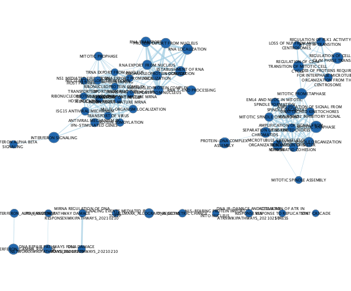

Figure 1: Enrichment Map pre-annotation

**2. Annotate your network - what parameters did you use to annotate the network. If you are using the default parameters make sure to list them as well.** **3. Make a publication ready figure - include this figure with proper legends in your notebook.**

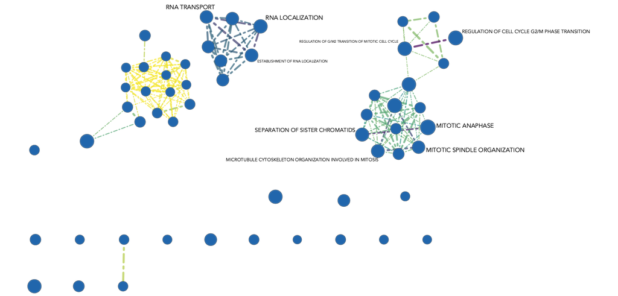

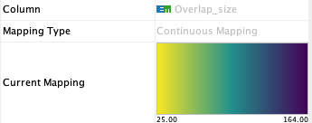

Figure 2: Annotated EnrichmentMap

**4. Collapse your network to a theme network. What are the major themes present in this analysis? Do they fit with the model? Are there any novel pathways or themes?**

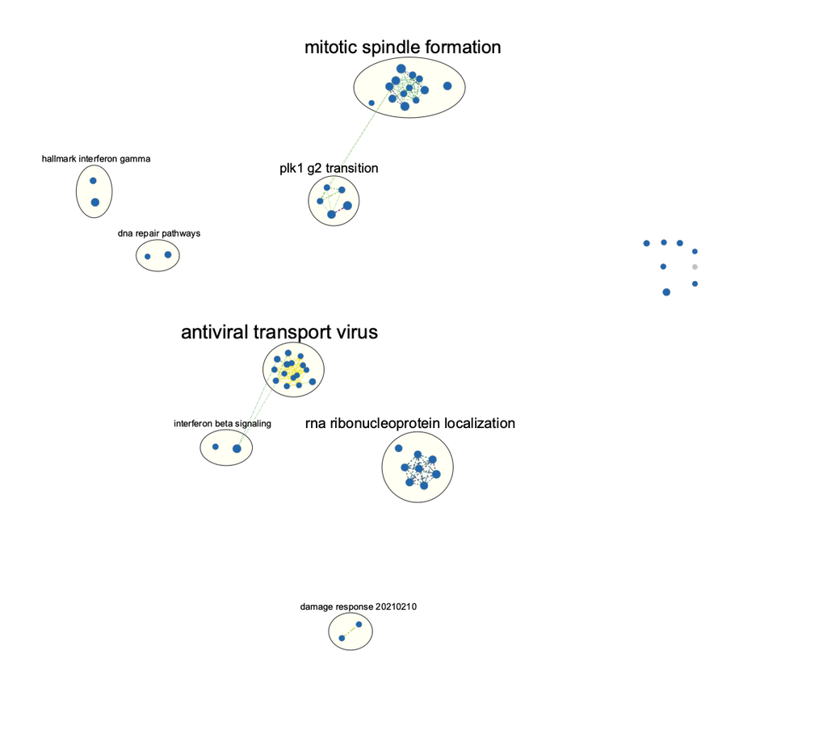

Figure 4: Theme Network

## Interpretation

**1. Do the enrichment results support conclusions or mechanism discussed in the original paper? How do these results differ from the results you got from Assignment #2 thresholded methods** In Assignment #2, I found that the top terms were related to cytokines and sex chromosomes (such as “Y-linked inheritance”). In the enrichment results here, the most visible terms are related to mitosis and RNA. The results seem different from the thresholded methods, but by looking at the pathways more in detail they still relate back to chromosomes and cytokines. This aligns with the conclusions in the original paper, as they mention that Alveolar Macrophages from healthy control subjects who were challenged with M. tuberculosis showed chromatin accessibility changes, which was not seen in the PLWH and PrEP subjects.

**2.Can you find evidence, i.e. publications, to support some of the results that you see. How does this evidence support your result?** The link between our HIV data and mitosis is shown as HIV-1 infectivity of cells seems to be enhanced during mitosis (Gibbons, Lee, & McKnight, 2019). An earlier paper showed how HIV-1 viron-associated protein (Vpr) induces defects in mitosis, cytokinesis, nuclear structure, and centrosomes, which can be seen in our themes network with several significant terms linked to mitosis and its functional structures (Belzile et al., 2007; Chang et al., 2004; Kurapati et al., 2015; Payne et al., 2018).

## Theme

**2.Choose a specific pathway or theme to investigate in more detail. Why did you choose this pathway or theme? Show the pathway or theme as a gene network or as a pathway diagram. Annotate the network or pathway with your original log fold expression values and p-values to show how it is effected in your model.**

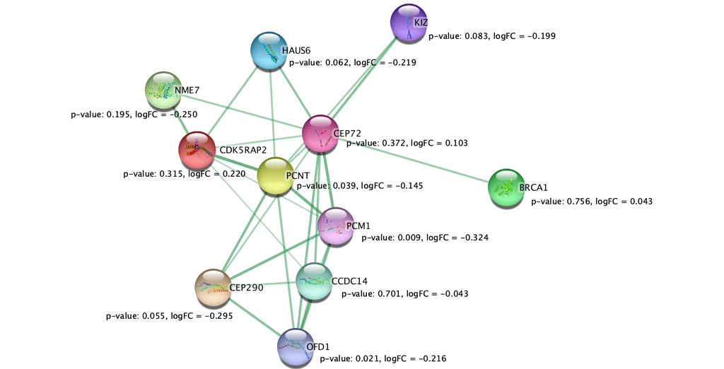

Figure 5: Mitotic Prophase Pathway in Homo sapiens